# Các lệnh R thường dùng khi thực hiện thống kê mô tả

**Biên soạn**

Duc Nguyen | Founder of [tuhocr.com](https://www.tuhocr.com/)

**Cập nhật**

2024 July 22

[text](https://applyr.netlify.app/codebase/quarto-descriptive-statistics/quarto-descriptive-statistics.txt) [web](https://applyr.netlify.app/codebase/quarto-descriptive-statistics/quarto-descriptive-statistics.html) ‍ ‍ ‍

# 1 Tình huống thường gặp

Bạn có file dữ liệu `df` gồm rất nhiều hàng và cột (trong bài này ta sử dụng dummy dataset để làm ví dụ minh họa). Việc đầu tiên cần làm là kiểm tra đặc điểm dữ liệu để đánh giá tổng quát toàn bộ dataset như thế nào nhằm có một hình dung cụ thể về dữ liệu trước khi thực hiện các bước phân tích sâu hơn.

Để tạo ra 1 file HTML table show full dataset, bạn sử dụng package `kableExtra`[^1]. [**View**](https://applyr.netlify.app/codebase/quarto-descriptive-statistics/output.html)

```r
df <- read.csv("students.csv")

library(kableExtra)
df %>% kbl(format = "html") %>%
  kable_styling(bootstrap_options = c("striped",
                                      "hover",
                                      "condensed",
                                      "bordered",
                                      "responsive")) %>%
  row_spec(0, bold = TRUE, align = "c", color = "white", background = "#1d6c00") %>%
  kable_classic(full_width = TRUE, html_font = "arial") -> output

save_kable(output, file = "output.html")
```

```r
df <- read.csv("students.csv")
head(df, n = 30) ### xem 30 dòng đầu của df
```

```
   no stud.id                        name gender age height weight   religion nc.score semester                      major                      minor score1 score2 online.tutorial graduated   salary
1   1  833917         Gonzales, Christina Female  19    160   64.8     Muslim     1.91      1st          Political Science            Social Sciences     NA     NA               0         0       NA
2   2  898539              Lozano, T'Hani Female  19    172   73.0      Other     1.56      2nd            Social Sciences Mathematics and Statistics     NA     NA               0         0       NA
3   3  379678              Williams, Hanh Female  22    168   70.6 Protestant     1.24      3rd            Social Sciences Mathematics and Statistics     45     46               0         0       NA
4   4  807564                 Nem, Denzel   Male  19    183   79.7      Other     1.37      2nd     Environmental Sciences Mathematics and Statistics     NA     NA               0         0       NA
5   5  383291             Powell, Heather Female  21    175   71.4   Catholic     1.46      1st     Environmental Sciences Mathematics and Statistics     NA     NA               0         0       NA
6   6  256074              Perez, Jadrian   Male  19    189   85.8   Catholic     1.34      2nd          Political Science Mathematics and Statistics     NA     NA               0         0       NA
7   7  754591               Clardy, Anita Female  21    156   65.9 Protestant     1.11      2nd          Political Science            Social Sciences     NA     NA               0         0       NA
8   8  146494        Allen, Rebecca Marie Female  21    167   65.7      Other     2.03      3rd          Political Science      Economics and Finance     58     62               0         0       NA
9   9  723584               Tracy, Robert   Male  18    195   94.4      Other     1.29      3rd      Economics and Finance     Environmental Sciences     57     67               0         0       NA
10 10  314281              Nimmons, Laura Female  18    165   66.0   Orthodox     1.19      2nd     Environmental Sciences Mathematics and Statistics     NA     NA               0         0       NA
11 11  200803             Lang, Mackenzie Female  22    162   66.8      Other     1.04      4th      Economics and Finance     Environmental Sciences     62     61               1         1 45254.11
12 12  444907          Rodriguez, Brianna Female  18    172   66.8      Other     3.81      3rd     Environmental Sciences      Economics and Finance     76     82               0         0       NA
13 13  354271 Covar Orendain, Christopher   Male  23    185   84.6   Orthodox     1.00      4th     Environmental Sciences Mathematics and Statistics     71     76               1         1 40552.79
14 14  317812              Lopez, Monique Female  20    158   64.4   Catholic     2.50      6th     Environmental Sciences            Social Sciences     66     70               1         1 27007.03
```

[output cut: 16 more lines]

# 2 Các lệnh kiểm tra dataset thường dùng

```r
dim(df) ### Kiểm tra dataset gồm bao nhiêu hàng và cột
```

```
[1] 8239   17
```

```r
str(df) ### Xem tổng quát cấu trúc dataset
```

```
'data.frame':   8239 obs. of  17 variables:
 $ no             : int  1 2 3 4 5 6 7 8 9 10 ...
 $ stud.id        : int  833917 898539 379678 807564 383291 256074 754591 146494 723584 314281 ...
 $ name           : chr  "Gonzales, Christina" "Lozano, T'Hani" "Williams, Hanh" "Nem, Denzel" ...
 $ gender         : chr  "Female" "Female" "Female" "Male" ...
 $ age            : int  19 19 22 19 21 19 21 21 18 18 ...
 $ height         : int  160 172 168 183 175 189 156 167 195 165 ...
 $ weight         : num  64.8 73 70.6 79.7 71.4 85.8 65.9 65.7 94.4 66 ...
 $ religion       : chr  "Muslim" "Other" "Protestant" "Other" ...
 $ nc.score       : num  1.91 1.56 1.24 1.37 1.46 1.34 1.11 2.03 1.29 1.19 ...
 $ semester       : chr  "1st" "2nd" "3rd" "2nd" ...
 $ major          : chr  "Political Science" "Social Sciences" "Social Sciences" "Environmental Sciences" ...
 $ minor          : chr  "Social Sciences" "Mathematics and Statistics" "Mathematics and Statistics" "Mathematics and Statistics" ...
 $ score1         : int  NA NA 45 NA NA NA NA 58 57 NA ...
 $ score2         : int  NA NA 46 NA NA NA NA 62 67 NA ...
 $ online.tutorial: int  0 0 0 0 0 0 0 0 0 0 ...
 $ graduated      : int  0 0 0 0 0 0 0 0 0 0 ...
 $ salary         : num  NA NA NA NA NA NA NA NA NA NA ...
```

```r
summary(df) ### Tóm tắt đặc điểm từng cột trong dataset
```

```
       no          stud.id           name              gender               age            height          weight        religion            nc.score       semester            major              minor               score1          score2     online.tutorial    graduated          salary
 Min.   :   1   Min.   :110250   Length:8239        Length:8239        Min.   :18.00   Min.   :135.0   Min.   : 51.4   Length:8239        Min.   :1.000   Length:8239        Length:8239        Length:8239        Min.   :30.00   Min.   :31.0   Min.   :0.0000   Min.   :0.0000   Min.   :11444
 1st Qu.:2060   1st Qu.:331223   Class :character   Class :character   1st Qu.:20.00   1st Qu.:163.0   1st Qu.: 66.5   Class :character   1st Qu.:1.460   Class :character   Class :character   Class :character   1st Qu.:58.00   1st Qu.:59.0   1st Qu.:0.0000   1st Qu.:0.0000   1st Qu.:35207
 Median :4120   Median :545132   Mode  :character   Mode  :character   Median :21.00   Median :171.0   Median : 71.8   Mode  :character   Median :2.040   Mode  :character   Mode  :character   Mode  :character   Median :70.00   Median :71.0   Median :0.0000   Median :0.0000   Median :41672
 Mean   :4120   Mean   :548911                                         Mean   :22.54   Mean   :171.4   Mean   : 73.0                      Mean   :2.166                                                            Mean   :68.17   Mean   :69.5   Mean   :0.3862   Mean   :0.2128   Mean   :42522
 3rd Qu.:6180   3rd Qu.:770808                                         3rd Qu.:23.00   3rd Qu.:180.0   3rd Qu.: 78.5                      3rd Qu.:2.780                                                            3rd Qu.:78.00   3rd Qu.:80.0   3rd Qu.:1.0000   3rd Qu.:0.0000   3rd Qu.:49373
 Max.   :8239   Max.   :989901                                         Max.   :64.00   Max.   :206.0   Max.   :116.0                      Max.   :4.000                                                            Max.   :97.00   Max.   :98.0   Max.   :1.0000   Max.   :1.0000   Max.   :75597
                                                                                                                                                                                                                   NA's   :3347    NA's   :3347                                     NA's   :6486
```

Vì giá trị `NA` missing values chỉ thể hiện ở numeric vector mà không thể hiện ở character vector. Vì vậy kết quả trong lệnh `summary()` chỉ để tham khảo sơ bộ khi đánh giá về tình trạng `NA` của bộ dữ liệu.

```r
### Lệnh này xác nhận là toàn bộ dataset có `NA` hay không.
### Nếu FALSE là chắc chắn không có `NA`, còn TRUE thì chắc chắn là có `NA`.
any(is.na(df))
```

```
[1] TRUE
```

## 2.1 Kiểm tra kỹ `class` từng cột

```r
sapply(df, class) ### Kiểm tra class từng cột.
```

```
             no         stud.id            name          gender             age          height          weight        religion        nc.score        semester           major           minor          score1          score2 online.tutorial       graduated          salary
      "integer"       "integer"     "character"     "character"       "integer"       "integer"       "numeric"     "character"       "numeric"     "character"     "character"     "character"       "integer"       "integer"       "integer"       "integer"       "numeric"
```

Ta chuyển toàn bộ các cột ở class `integer` sang class `numeric` (nếu cần thiết). Ở đây mình làm ví dụ minh họa để có code mẫu áp dụng cho các trường hợp tương tự.

```r
### Tách ra vector chứa kết quả kiểm tra class từng cột
class_tung_cot <- sapply(df, class, simplify = TRUE, USE.NAMES = TRUE)
### Tìm vị trí index của các cột có class là `integer`
integer_index_cot <- grep(pattern = "integer", ignore.case = FALSE, fixed = TRUE, x = class_tung_cot)
### Tách ra tên các cột có class `integer`
ten_cot_integer <- names(class_tung_cot)[integer_index_cot]
### Chuyển toàn bộ các cột `integer` này về dạng `numeric`
df[, ten_cot_integer] <- lapply(df[, ten_cot_integer], as.numeric)
### Kiểm tra lại thì thấy toàn bộ các cột `integer` đã chuyển qua dạng `numeric`
sapply(df, class, simplify = TRUE, USE.NAMES = TRUE)
```

```
             no         stud.id            name          gender             age          height          weight        religion        nc.score        semester           major           minor          score1          score2 online.tutorial       graduated          salary
      "numeric"       "numeric"     "character"     "character"       "numeric"       "numeric"       "numeric"     "character"       "numeric"     "character"     "character"     "character"       "numeric"       "numeric"       "numeric"       "numeric"       "numeric"
```

## 2.2 Xác nhận mỗi dòng (observation, row) là một quan sát riêng biệt

Để tăng mức độ tự tin khi thao tác với dữ liệu, bạn cần xác nhận là mỗi dòng (ở đây là mỗi sinh viên) thì dữ liệu là duy nhất, không có lặp lại. Việc này rất quan trọng để tránh bị trùng lắp (trong trường hợp dataset ở dạng semi-long) để ta tìm cách trải dữ liệu ra làm sao thu được dạng true long hoặc true wide, tức là mỗi một dòng là một quan sát riêng biệt.

```r
### Thông thường trong các dataset luôn có cột ID để làm cơ sở theo dõi thông tin,
### nếu không có cột ID thì bạn cần tạo ra cột ID để thuận tiện xử lý sau này (nếu cần)
### Kiểm tra thông tin ở cột ID sinh viên xem có trùng lắp hay không,
### Lệnh unique() trả về kết quả của toàn bộ các giá trị xuất hiện duy nhất trong cột ID
### Lệnh length() giúp đếm tổng chiều dài của vector
length(unique(df$stud.id))
```

```
[1] 8239
```

Như vậy ta xác nhận xem tổng số hàng của dataset `df` có bằng với tổng số giá trị ID riêng biệt ở cột `stud.id` hay không. Nếu là `TRUE` thì chắc chắn là mỗi một dòng là một sinh viên riêng biệt.

```r
identical(dim(df)[1], length(unique(df$stud.id)))
```

```
[1] TRUE
```

Cách 2 là ta dùng lệnh `duplicated()`

```r
### Lệnh này trả về vector logical check cho mỗi giá trị trong vector stud.id
### Nếu có trùng lặp thì sẽ có TRUE, còn nếu không có trùng lặp sẽ là FALSE
check_duplicated <- duplicated(df$stud.id)
### Lệnh all này sẽ trả về kết quả TRUE nếu toàn bộ giá trị trong vector !check_duplicated
### là TRUE, nghĩa là không có trùng lặp
all(!check_duplicated)
```

```
[1] TRUE
```

Cách 3 là ta dùng lệnh `anyDuplicated()`

```r
### Để thuận tiện thì ta dùng lệnh này, nếu kết quả trả về 0 nghĩa là không có trùng lặp
anyDuplicated(df$stud.id)
```

```
[1] 0
```

## 2.3 Dùng lệnh `table()` để kiểm tra giá trị `NA` ở từng cột

Lệnh `table()` là một lệnh rất mạnh trong R. Ta nên dùng tham số `useNA = "ifany"` nhằm thể hiện luôn số lượng `NA` nếu có trong vector đang kiểm tra.

```r
options(width = 120)
check_na <- lapply(X = df[, !(names(df) %in% c("no", "stud.id", "name"))], ### Bỏ 3 cột đầu vì không cần thiết phải check `NA`
                   FUN = table,
                   ### Tham số `gender` ở vị trí hàng, tham số `major` ở vị trí cột
                   useNA = "ifany")

check_na
```

```
$gender

Female   Male
  4110   4129

$age

  18   19   20   21   22   23   24   25   26   27   28   29   30   31   32   33   34   35   36   37   38   39   40   41
 259  987 1497 1729 1508  948  485  252  106   39   21   15    9   11   13   11   12   15    9   12    8   10    7   18
  42   43   44   45   46   47   48   49   50   51   52   53   54   55   56   57   58   59   60   61   62   63   64
  16   14   17   11    9   15    5   11   12   10    9    6   14   16   10   12    9   11   16   10    9   13    3

$height

135 139 140 141 142 143 144 145 146 147 148 149 150 151 152 153 154 155 156 157 158 159 160 161 162 163 164 165 166 167
  1   2   4   3   9   8   8  15  24  17  32  38  56  49  71  70 106 106 157 137 155 177 236 177 246 200 279 209 254 234
168 169 170 171 172 173 174 175 176 177 178 179 180 181 182 183 184 185 186 187 188 189 190 191 192 193 194 195 196 197
287 246 293 241 294 224 298 227 292 198 269 210 237 189 243 185 183 140 166 112 146  80  89  57  63  39  43  38  24  12
198 199 200 201 202 203 206
  8   5   7   6   4   2   2

$weight

 51.4    54  54.3  54.6  54.7  54.8    55  55.2  55.3  55.4  55.5  55.7  55.9  56.1  56.2  56.3  56.4  56.5  56.6  56.7
    1     1     1     1     1     1     2     1     1     2     1     1     2     5     5     1     4     5     2     3
 56.8  56.9    57  57.1  57.2  57.3  57.4  57.5  57.6  57.7  57.8  57.9    58  58.1  58.2  58.3  58.4  58.5  58.6  58.7
    2     3     4     2     2     2     2     4     5     4     7     6     7     3     8     7     4    10     8     9
 58.8  58.9    59  59.1  59.2  59.3  59.4  59.5  59.6  59.7  59.8  59.9    60  60.1  60.2  60.3  60.4  60.5  60.6  60.7
    8    13     5     7     5     8     8    10    12    14    17    13     9    17    11    12    16    14    12    15
 60.8  60.9    61  61.1  61.2  61.3  61.4  61.5  61.6  61.7  61.8  61.9    62  62.1  62.2  62.3  62.4  62.5  62.6  62.7
   20    16    11    19    11    22    28    16    24    18    15    30    24    28    20    19    19    24    36    20
 62.8  62.9    63  63.1  63.2  63.3  63.4  63.5  63.6  63.7  63.8  63.9    64  64.1  64.2  64.3  64.4  64.5  64.6  64.7
   30    25    37    23    34    35    40    34    25    32    33    26    28    20    31    24    30    39    29    36
 64.8  64.9    65  65.1  65.2  65.3  65.4  65.5  65.6  65.7  65.8  65.9    66  66.1  66.2  66.3  66.4  66.5  66.6  66.7
   43    36    41    28    34    41    31    30    35    38    49    41    47    52    39    38    32    33    39    36
 66.8  66.9    67  67.1  67.2  67.3  67.4  67.5  67.6  67.7  67.8  67.9    68  68.1  68.2  68.3  68.4  68.5  68.6  68.7
   36    47    30    57    35    43    36    34    34    54    38    30    42    37    36    51    34    44    48    40
 68.8  68.9    69  69.1  69.2  69.3  69.4  69.5  69.6  69.7  69.8  69.9    70  70.1  70.2  70.3  70.4  70.5  70.6  70.7
   49    37    36    40    46    34    38    33    38    36    38    37    40    34    42    34    25    23    47    48
 70.8  70.9    71  71.1  71.2  71.3  71.4  71.5  71.6  71.7  71.8  71.9    72  72.1  72.2  72.3  72.4  72.5  72.6  72.7
```

[output cut: 452 more lines]

```
          1           1           1           1           1           1           1           1           1           1
62192.25594 62307.04322 62360.01908 62478.72933 62858.83411  62887.0343 63154.33225 63183.62447 63199.06624 63375.37993
          1           1           1           1           1           1           1           1           1           1
 63426.3478  63633.9008 64012.32086 64050.00926  64052.1951 64271.11979 64486.40644 64525.11155 64539.88869 64548.11004
          1           1           1           1           1           1           1           1           1           1
64592.71068 64707.81886  65013.0088 65107.53227 65353.38112 65389.89613 65397.21855 65422.04962 65441.30143  65635.9975
          1           1           1           1           1           1           1           1           1           1
65776.22733 65956.82189 66365.12731  66416.6068 66473.13653 66607.29432 66636.72062 66922.11848 67230.09536 67278.11292
          1           1           1           1           1           1           1           1           1           1
67357.92615 67362.35569 67379.49375 67893.55998  68324.0096 68576.68656 68980.28115 68985.59811 69348.60687 69351.41417
          1           1           1           1           1           1           1           1           1           1
69518.73751 69521.13573 70094.84888 70324.83769 70744.63869 70931.61002 71467.89992 71537.22292  71612.7081 72787.28668
          1           1           1           1           1           1           1           1           1           1
73980.21462 75530.38563 75596.79344        <NA>
          1           1           1        6486
```

Kết quả trả về là bảng tần số ở từng cột, nếu có `NA` như ở trường hợp cột `salaray` thì sẽ hiện ra ở dòng cuối. Trong trường hợp kết quả này quá nhiều cột, ta chỉ quan tâm tách ra những cột nào có giá trị `NA` và muốn biết có bao nhiêu `NA` trong cột đó (dù là `character` hay `numeric`) thì ta sẽ làm thêm một bước kiểm tra sau.

```r
### Lệnh này sẽ kiểm từng thành phần trong list `check_na` sau đó trả về kết quả
### Những thành phần nào (cột nào trong df) có bao nhiêu giá trị `NA`
check_1 <- lapply(check_na, function(x) {
                                        x[which(is.na(names(x)))]
                                        }
                  )

### Build function kiểm tra ruột của từng thành phần trong list có giá trị hay không
is.integer0 <- function(x) {
  is.integer(x) && length(x) == 0L
}

### Kiểm tra từng thành phần trong check_1 có giá trị hay không
check_2 <- lapply(check_1, is.integer0)

### Trích xuất những cột có giá trị missing value
check_1[!unlist(check_2)]
```

```
$score1
<NA>
3347

$score2
<NA>
3347

$salary
<NA>
6486
```

## 2.4 Thể hiện giá trị `NA` trên toàn bộ dataset qua heatmap

### 2.4.1 Cách 1: Sử dụng package `mice`

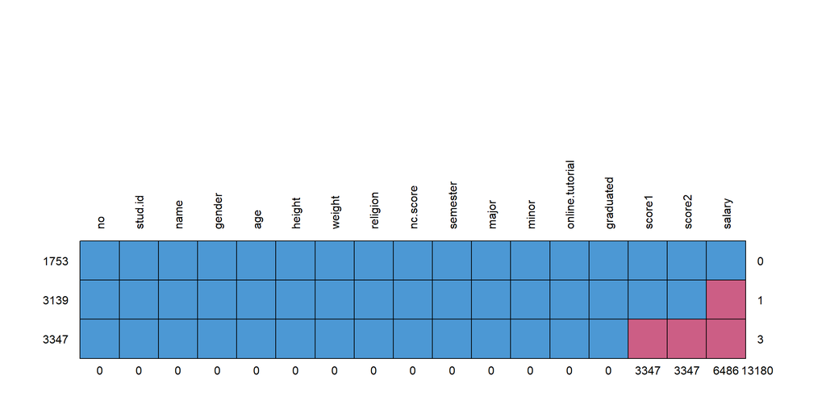

```
     no stud.id name gender age height weight religion nc.score semester major minor online.tutorial graduated score1 score2 salary
1753  1       1    1      1   1      1      1        1        1        1     1     1               1         1      1      1      1     0
3139  1       1    1      1   1      1      1        1        1        1     1     1               1         1      1      1      0     1
3347  1       1    1      1   1      1      1        1        1        1     1     1               1         1      0      0      0     3
      0       0    0      0   0      0      0        0        0        0     0     0               0         0   3347   3347   6486 13180
```

```r
library(mice)
mice::md.pattern(df, plot = TRUE, rotate.names = TRUE)
```

Kết quả này đọc là có 1753 sinh viên có đủ các thông tin ở tất cả các cột, 3139 sinh viên có đủ thông tin (chỉ trừ cột `salary` là có missing value), 3347 sinh viên có đủ thông tin (chỉ trừ các cột `score1`, `score2`, và `salary`). Có tổng cộng 13180 giá trị `NA` trong toàn bộ dataset. Cụ thể cách phân tích kết quả missing value theo package `mice` được trình bày [**ở đây**](https://thongkesinhhoc.com/ky-thuat-kiem-tra-missing-value)

### 2.4.2 Cách 2: Sử dụng package `VIM`

Sử dụng đồ thị này để thể hiện tỷ lệ % giá trị `NA` trên toàn dataset.

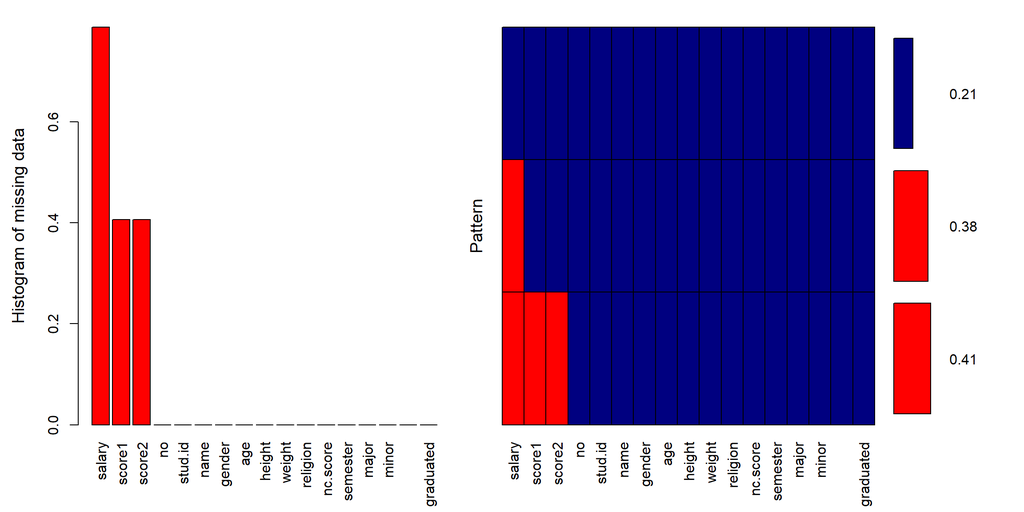

```
 Variables sorted by number of missings:
        Variable     Count
          salary 0.7872315
          score1 0.4062386
          score2 0.4062386
              no 0.0000000
         stud.id 0.0000000
            name 0.0000000
          gender 0.0000000
             age 0.0000000
          height 0.0000000
          weight 0.0000000
        religion 0.0000000
        nc.score 0.0000000
        semester 0.0000000
           major 0.0000000
           minor 0.0000000
 online.tutorial 0.0000000
       graduated 0.0000000
```

```r
library(VIM)
aggr_plot <- VIM::aggr(df,
                       col = c("navyblue", "red"),
                       numbers = TRUE,
                       sortVars = TRUE,
                       labels = names(data),
                       cex.axis = 1,
                       gap = 3,
                       ylab = c("Histogram of missing data", "Pattern"))
```

Ta có thể so sánh từng cặp chỉ tiêu với nhau thông qua đồ thị này, với các biện luận tham khảo ở đây[^2].

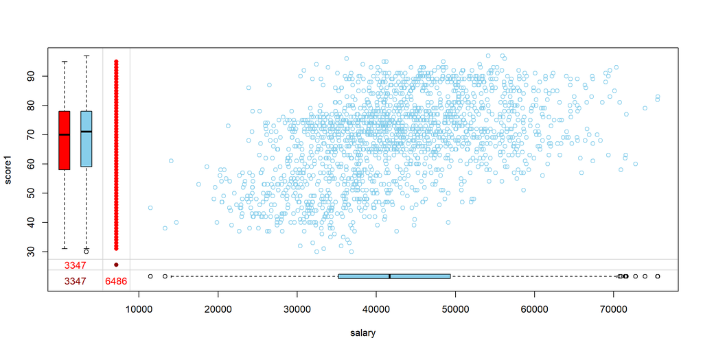

```r
VIM::marginplot(df[, c("salary", "score1")])
```

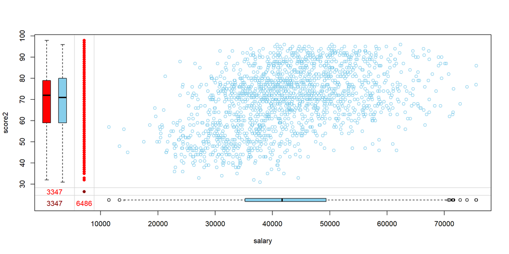

```r
VIM::marginplot(df[, c("salary", "score2")])
```

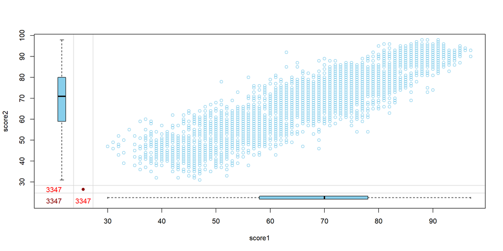

```r
VIM::marginplot(df[, c("score1", "score2")])
```

# 3 Các lệnh group và summary dữ liệu

Ở thời điểm này, ta đã có cái nhìn tổng quát về bộ dữ liệu. Lúc này việc phân tích thống kê mô tả sẽ đi theo câu hỏi nghiên cứu/chủ đề mà bạn quan tâm để làm cơ sở chọn ra những biến/cột/variable phân tích mô tả cụ thể hơn. Mình chọn quan tâm về số lượng nam và nữ ở cột giới tính `gender` theo học các ngành `major` trong bộ dữ liệu này.

## 3.1 Áp dụng các lệnh tạo bảng summary

### 3.1.1 Sử dụng lệnh `table()` cho hai tham số

```r
### Tham số `gender` ở vị trí hàng, tham số `major` ở vị trí cột
table(df$gender, df$major, useNA = "ifany")
```

```
         Biology Economics and Finance Environmental Sciences Mathematics and Statistics Political Science Social Sciences
  Female     959                   461                    745                        276               978             691
  Male       638                   863                    881                        949               477             321
```

Nếu dùng lệnh `table()` cho ba tham số sẽ tạo ra dạng array 3 chiều, chẻ ra thành từng matrix 2 chiều.

```r
### Tham số `religion` ở vị trí thứ 3 sẽ được tách ra tương ứng các matrix giữa `gender` và `major`
table(df$gender, df$major, df$religion, useNA = "ifany")
```

```
, ,  = Catholic


         Biology Economics and Finance Environmental Sciences Mathematics and Statistics Political Science Social Sciences
  Female     322                   162                    244                         95               307             226
  Male       223                   301                    313                        344               161              99

, ,  = Muslim


         Biology Economics and Finance Environmental Sciences Mathematics and Statistics Political Science Social Sciences
  Female      47                    14                     35                          8                45              27
  Male        22                    28                     38                         32                21              13

, ,  = Orthodox


         Biology Economics and Finance Environmental Sciences Mathematics and Statistics Political Science Social Sciences
  Female      71                    32                     62                         24                68              52
  Male        29                    55                     70                         59                38              25

, ,  = Other


         Biology Economics and Finance Environmental Sciences Mathematics and Statistics Political Science Social Sciences
  Female     313                   157                    229                         86               328             246
  Male       221                   273                    280                        296               143             116

, ,  = Protestant


         Biology Economics and Finance Environmental Sciences Mathematics and Statistics Political Science Social Sciences
  Female     206                    96                    175                         63               230             140
  Male       143                   206                    180                        218               114              68
```

### 3.1.2 Add margins vào table

Tạo bảng summary cho hai tham số `gender` và `major`

```r
gender_major <- table(df$gender, df$major, useNA = "ifany")

names(dimnames(gender_major)) <- c("Gender", "Major")

addmargins(A = gender_major,
           margin = seq_along(dim(gender_major)),
           FUN = sum,
           quiet = TRUE)
```

```
        Major
Gender   Biology Economics and Finance Environmental Sciences Mathematics and Statistics Political Science Social Sciences  sum
  Female     959                   461                    745                        276               978             691 4110
  Male       638                   863                    881                        949               477             321 4129
  sum       1597                  1324                   1626                       1225              1455            1012 8239
```

Tạo bảng summary cho ba tham số `gender` và `major` và `religion`

```r
gender_major_religion <- table(df$gender, df$major, df$religion, useNA = "ifany")

names(dimnames(gender_major_religion)) <- c("Gender", "Major", "Religion")

addmargins(A = gender_major_religion,
           margin = seq_along(dim(gender_major_religion)),
           FUN = sum,
           quiet = TRUE)
```

```
, , Religion = Catholic

        Major
Gender   Biology Economics and Finance Environmental Sciences Mathematics and Statistics Political Science Social Sciences  sum
  Female     322                   162                    244                         95               307             226 1356
  Male       223                   301                    313                        344               161              99 1441
  sum        545                   463                    557                        439               468             325 2797

, , Religion = Muslim

        Major
Gender   Biology Economics and Finance Environmental Sciences Mathematics and Statistics Political Science Social Sciences  sum
  Female      47                    14                     35                          8                45              27  176
  Male        22                    28                     38                         32                21              13  154
  sum         69                    42                     73                         40                66              40  330

, , Religion = Orthodox

        Major
Gender   Biology Economics and Finance Environmental Sciences Mathematics and Statistics Political Science Social Sciences  sum
  Female      71                    32                     62                         24                68              52  309
  Male        29                    55                     70                         59                38              25  276
  sum        100                    87                    132                         83               106              77  585

, , Religion = Other

        Major
Gender   Biology Economics and Finance Environmental Sciences Mathematics and Statistics Political Science Social Sciences  sum
  Female     313                   157                    229                         86               328             246 1359
  Male       221                   273                    280                        296               143             116 1329
  sum        534                   430                    509                        382               471             362 2688

, , Religion = Protestant

        Major
Gender   Biology Economics and Finance Environmental Sciences Mathematics and Statistics Political Science Social Sciences  sum
  Female     206                    96                    175                         63               230             140  910
  Male       143                   206                    180                        218               114              68  929
  sum        349                   302                    355                        281               344             208 1839

, , Religion = sum

        Major
Gender   Biology Economics and Finance Environmental Sciences Mathematics and Statistics Political Science Social Sciences  sum
  Female     959                   461                    745                        276               978             691 4110
  Male       638                   863                    881                        949               477             321 4129
  sum       1597                  1324                   1626                       1225              1455            1012 8239
```

### 3.1.3 Sử dụng lệnh `prop.table()`

```r
### Lệnh này trả về tỷ lệ giữa nam và nữ trong cùng vector `gender`
prop.table(table(df$gender), margin = NULL)
```

```
   Female      Male
0.4988469 0.5011531
```

```r
### Nếu có 2 tham số trở lên thì các bạn chú ý tham số margin nhé
prop.table(table(df$gender, df$major, useNA = "ifany"), margin = NULL)
```

```
            Biology Economics and Finance Environmental Sciences Mathematics and Statistics Political Science Social Sciences
  Female 0.11639762            0.05595339             0.09042360                 0.03349921        0.11870373      0.08386940
  Male   0.07743658            0.10474572             0.10693045                 0.11518388        0.05789538      0.03896104
```

```r
addmargins(A = prop.table(table(df$gender, df$major, useNA = "ifany"), margin = NULL),
           margin = seq_along(dim(prop.table(table(df$gender, df$major, useNA = "ifany"), margin = NULL))),
           FUN = sum,
           quiet = TRUE)
```

```
            Biology Economics and Finance Environmental Sciences Mathematics and Statistics Political Science Social Sciences        sum
  Female 0.11639762            0.05595339             0.09042360                 0.03349921        0.11870373      0.08386940 0.49884695
  Male   0.07743658            0.10474572             0.10693045                 0.11518388        0.05789538      0.03896104 0.50115305
  sum    0.19383420            0.16069911             0.19735405                 0.14868309        0.17659910      0.12283044 1.00000000
```

```r
addmargins(A = prop.table(table(df$gender, df$major, useNA = "ifany"), margin = 1),
           margin = seq_along(dim(prop.table(table(df$gender, df$major, useNA = "ifany"), margin = 1))),
           FUN = sum,
           quiet = TRUE)
```

```
            Biology Economics and Finance Environmental Sciences Mathematics and Statistics Political Science Social Sciences        sum
  Female 0.23333333            0.11216545             0.18126521                 0.06715328        0.23795620      0.16812652 1.00000000
  Male   0.15451683            0.20900945             0.21336885                 0.22983773        0.11552434      0.07774279 1.00000000
  sum    0.38785017            0.32117490             0.39463406                 0.29699102        0.35348054      0.24586932 2.00000000
```

```r
addmargins(A = prop.table(table(df$gender, df$major, useNA = "ifany"), margin = 2),
           margin = seq_along(dim(prop.table(table(df$gender, df$major, useNA = "ifany"), margin = 2))),
           FUN = sum,
           quiet = TRUE)
```

```
           Biology Economics and Finance Environmental Sciences Mathematics and Statistics Political Science Social Sciences       sum
  Female 0.6005009             0.3481873              0.4581796                  0.2253061         0.6721649       0.6828063 2.9871452
  Male   0.3994991             0.6518127              0.5418204                  0.7746939         0.3278351       0.3171937 3.0128548
  sum    1.0000000             1.0000000              1.0000000                  1.0000000         1.0000000       1.0000000 6.0000000
```

## 3.2 Áp dụng các lệnh summary trong package `dplyr`

```r
library(dplyr)

df |> dplyr::group_by(gender, religion) |>
  dplyr::summarise(trung_binh_age = mean(age),
                   trung_vi_age = median(age),
                   do_lech_chuan_age = sd(age),
                   so_luong = n(),
                   max_age = max(age),
                   min_age = min(age),
                   tong_so_tuoi = sum(age)) -> summary_all

summary_all
```

```
# A tibble: 10 × 9
# Groups:   gender [2]
   gender religion   trung_binh_age trung_vi_age do_lech_chuan_age so_luong max_age min_age tong_so_tuoi
   <chr>  <chr>               <dbl>        <dbl>             <dbl>    <int>   <dbl>   <dbl>        <dbl>
 1 Female Catholic             22.4           21              5.65     1356      63      18        30435
 2 Female Muslim               22.3           21              6.14      176      62      18         3932
 3 Female Orthodox             22.5           21              5.95      309      63      18         6961
 4 Female Other                22.6           21              6.27     1359      64      18        30653
 5 Female Protestant           23.0           21              7.23      910      64      18        20933
 6 Male   Catholic             22.4           21              5.69     1441      63      18        32290
 7 Male   Muslim               22.3           21              4.56      154      55      18         3438
 8 Male   Orthodox             22.6           21              6.03      276      63      18         6232
 9 Male   Other                22.8           21              6.52     1329      63      18        30240
10 Male   Protestant           22.2           21              5.17      929      63      18        20606
```

```r
library(dplyr)

df |> dplyr::group_by(major) |>
  dplyr::summarise(so_luong_mon = n_distinct(major),
                   so_nguoi_theo_hoc = n()) |>
  print(n = Inf)
```

```
# A tibble: 6 × 3
  major                      so_luong_mon so_nguoi_theo_hoc
  <chr>                             <int>             <int>
1 Biology                               1              1597
2 Economics and Finance                 1              1324
3 Environmental Sciences                1              1626
4 Mathematics and Statistics            1              1225
5 Political Science                     1              1455
6 Social Sciences                       1              1012
```

```r
library(dplyr)

df |> dplyr::group_by(major, gender) |>
  dplyr::summarise(so_nguoi_theo_hoc = n()) -> df_major_gender

df_major_gender |> print(n = Inf)
```

```
# A tibble: 12 × 3
# Groups:   major [6]
   major                      gender so_nguoi_theo_hoc
   <chr>                      <chr>              <int>
 1 Biology                    Female               959
 2 Biology                    Male                 638
 3 Economics and Finance      Female               461
 4 Economics and Finance      Male                 863
 5 Environmental Sciences     Female               745
 6 Environmental Sciences     Male                 881
 7 Mathematics and Statistics Female               276
 8 Mathematics and Statistics Male                 949
 9 Political Science          Female               978
10 Political Science          Male                 477
11 Social Sciences            Female               691
12 Social Sciences            Male                 321
```

```r
# df |> dplyr::group_by(major, minor) |>
#   dplyr::summarise(so_luong_mon = n_distinct(major),
#                    so_nguoi_theo_hoc = n()) |>
#   print(n = Inf)
#
# df |> dplyr::group_by(major, minor) |>
#   dplyr::summarise(so_luong_mon = n_distinct(minor),
#                    so_nguoi_theo_hoc = n())|>
#   print(n = Inf)
```

# 4 Vẽ đồ thị mô tả dữ liệu

## 4.1 Vẽ đồ thị cột

### 4.1.1 Đồ thị cột side-by-side

**Nếu dataset ở dạng như sau thì khi ta vẽ đồ thị cột sẽ dùng theo dạng formula `y ~ x1 + x2`**

```r
df_major_gender
```

```
# A tibble: 12 × 3
# Groups:   major [6]
   major                      gender so_nguoi_theo_hoc
   <chr>                      <chr>              <int>
 1 Biology                    Female               959
 2 Biology                    Male                 638
 3 Economics and Finance      Female               461
 4 Economics and Finance      Male                 863
 5 Environmental Sciences     Female               745
 6 Environmental Sciences     Male                 881
 7 Mathematics and Statistics Female               276
 8 Mathematics and Statistics Male                 949
 9 Political Science          Female               978
10 Political Science          Male                 477
11 Social Sciences            Female               691
12 Social Sciences            Male                 321
```

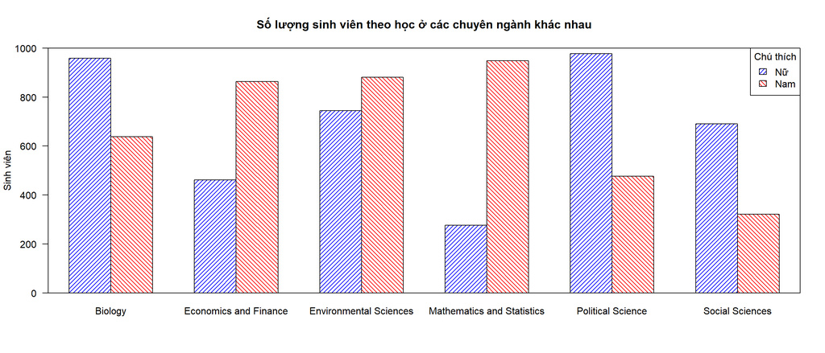

```r
barplot(so_nguoi_theo_hoc ~ gender + major,
              data = df_major_gender,
              beside = TRUE,
              col = c("blue", "red"),
              angle = c(45, 135),
              density = 20,
              xlab = "",
              ylab = "Sinh viên",
              yaxs = "i",
              ylim = c(0, 1000),
              xaxs = "i",
              xlim = c(0.5, 18.5),
              # xaxt = "n",
              main = "Số lượng sinh viên theo học ở các chuyên ngành khác nhau",
              width = 1,
              las = 1)

legend(x = "topright",
       y = NULL,
       title = "Chú thích",
       legend = c("Nữ", "Nam"),
       col = c("blue", "red"),
       fill = c("blue", "red"),
       angle = c(45, 135),
       density = 20)

box()
```

**Nếu dataset ở dạng `table` hay `matrix` thì ta vẽ trực tiếp bằng lệnh `barplot()` với chính table đó.**

```r
student_gender_major <- table(df$gender, df$major)
student_gender_major
```

```
         Biology Economics and Finance Environmental Sciences Mathematics and Statistics Political Science Social Sciences
  Female     959                   461                    745                        276               978             691
  Male       638                   863                    881                        949               477             321
```

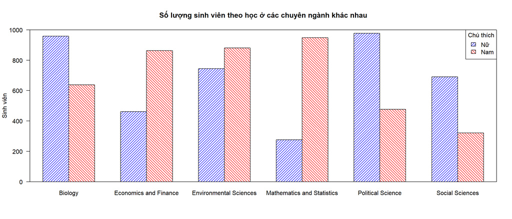

```r
barplot(height = student_gender_major,
              beside = TRUE,
              col = c("blue", "red"),
              angle = c(45, 135),
              density = 20,
              xlab = "",
              ylab = "Sinh viên",
              yaxs = "i",
              ylim = c(0, 1000),
              xaxs = "i",
              xlim = c(0.5, 18.5),
              # xaxt = "n",
              main = "Số lượng sinh viên theo học ở các chuyên ngành khác nhau",
              width = 1,
              las = 1)

legend(x = "topright",
       y = NULL,
       title = "Chú thích",
       legend = c("Nữ", "Nam"),
       col = c("blue", "red"),
       fill = c("blue", "red"),
       angle = c(45, 135),
       density = 20)

box()
```

### 4.1.2 Đồ thị cột stacked barchart

```r
barplot(height = student_gender_major,
              beside = FALSE,
              col = c("blue", "red"),
              angle = c(45, 135),
              density = 20,
              xlab = "",
              ylab = "Sinh viên",
              yaxs = "i",
              ylim = c(0, 2000),
              xaxs = "i",
              xlim = c(0, 7.4),
              # xaxt = "n",
              main = "Số lượng sinh viên theo học ở các chuyên ngành khác nhau",
              width = 1,
              space = 0.2,
              las = 1)

par("usr")
```

```
[1]    0.0    7.4    0.0 2000.0
```

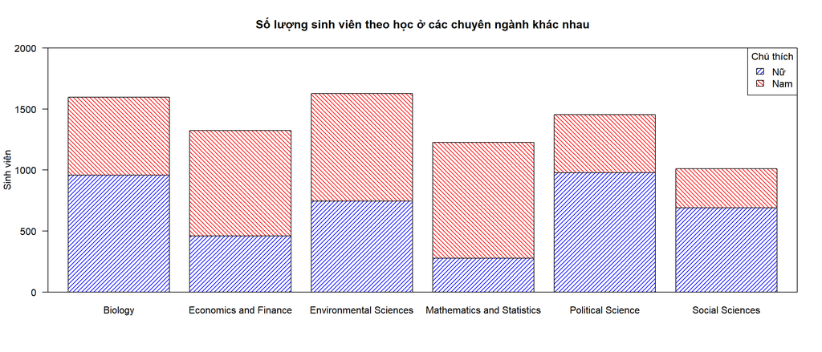

```r
legend(x = "topright",
       y = NULL,
       title = "Chú thích",
       legend = c("Nữ", "Nam"),
       col = c("blue", "red"),
       fill = c("blue", "red"),
       angle = c(45, 135),
       density = 20)

box()
```

### 4.1.3 Đồ thị cột percent stacked barchart

```r
percent_1 <- prop.table(table(df$gender, df$major), margin = 2)
percent_1
```

```
           Biology Economics and Finance Environmental Sciences Mathematics and Statistics Political Science Social Sciences
  Female 0.6005009             0.3481873              0.4581796                  0.2253061         0.6721649       0.6828063
  Male   0.3994991             0.6518127              0.5418204                  0.7746939         0.3278351       0.3171937
```

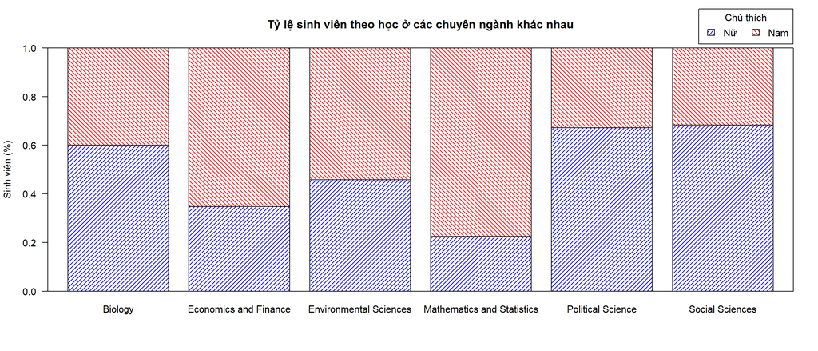

```r
barplot(height = percent_1,
              beside = FALSE,
              col = c("blue", "red"),
              angle = c(45, 135),
              density = 20,
              xlab = "",
              ylab = "Sinh viên (%)",
              yaxs = "i",
              ylim = c(0, 1),
              xaxs = "i",
              xlim = c(0, 7.4),
              # xaxt = "n",
              main = "Tỷ lệ sinh viên theo học ở các chuyên ngành khác nhau",
              width = 1,
              space = 0.2,
              las = 1)

# par("usr")

legend(x = 6.461,
       y = 1.16,
       title = "Chú thích",
       legend = c("Nữ", "Nam"),
       horiz = TRUE,
       col = c("blue", "red"),
       fill = c("blue", "red"),
       angle = c(45, 135),
       density = 20,
       xpd = TRUE)

box(which = "plot", col = "black")
```

```r
# box(which = "figure", col = "red")
```

## 4.2 Vẽ đồ thị đường

Ta quan tâm về `salary` và `age` xem có mối tương quan như thế nào.

```r
### tách ra dataset clean

df_salary <- df[, c("age", "gender", "salary")]
df_salary <- na.omit(df_salary)

df_salary |> dplyr::arrange(age, salary) -> df_salary

head(df_salary, n = 30)
```

```
   age gender   salary
1   18 Female 21000.25
2   18 Female 22313.33
3   18 Female 25979.07
4   18 Female 29178.47
5   18 Female 29550.79
6   18 Female 30062.71
7   18 Female 31266.92
8   18 Female 32038.41
9   18 Female 32943.41
10  18 Female 32966.91
11  18   Male 33908.18
12  18   Male 34460.44
13  18 Female 34492.08
14  18 Female 35507.83
```

[output cut: 16 more lines]

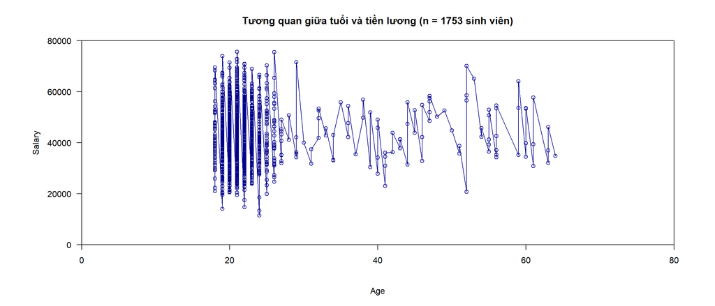

```r
options(scipen = 1e9)

oldpar <- par(no.readonly = TRUE)
par(mar = c(6, 8, 4, 4))
par(mgp = c(4, 1, 0))
plot(x = df_salary$age,
     y = df_salary$salary,
     type = "o",
     col = "darkblue",
     xlim = c(0, 80),
     ylim = c(0, 80000),
     las = 1,
     xaxs = "i",
     yaxs = "i",
     xlab = "Age",
     ylab = "Salary",
     main = paste0("Tương quan giữa tuổi và tiền lương (n = ",
                  dim(df_salary)[1], " sinh viên)"),
     lwd = 1,
     lty = 1,
     bty = "o")
```

```r
par(oldpar)
```

## 4.3 Vẽ đồ thị hộp

Ta cắt vector `age` theo các độ tuổi khác nhau để thuận tiện vẽ đồ thị hộp.

```r
df_salary$group_age <- cut(x = df_salary$age,
                           breaks = c(0, 20, 30, 40, 50, 60, 70),
                           labels = c("≤ 20",
                                      "20 < age ≤ 30",
                                      "30 < age ≤ 40",
                                      "40 < age ≤ 50",
                                      "50 < age ≤ 60",
                                      "> 60"))

df_salary |> dplyr::arrange(age, salary) -> df_salary

as.data.frame(table(df_salary$group_age))
```

```
           Var1 Freq
1          ≤ 20  577
2 20 < age ≤ 30 1093
3 30 < age ≤ 40   24
4 40 < age ≤ 50   25
5 50 < age ≤ 60   27
6          > 60    7
```

```r
# sample kiểu base R
# sample_x <- sample(1:nrow(df_salary), size = 30)
# df_salary[sample_x, ] -> df_sample

# sample kiểu dplyr (ngẫu nhiên)
# dplyr::sample_n(tbl = df_salary, size = 30, replace = FALSE) |> dplyr::arrange(age, salary)

set.seed(1)

# sample kiểu dplyr (ngẫu nhiên theo từng nhóm factor)
df_salary |> dplyr::group_by(group_age) |>
  dplyr::sample_frac(size = 0.05, replace = FALSE) |>
  dplyr::arrange(age, salary)-> sample_df

as.data.frame(sample_df)
```

```
   age gender   salary     group_age
1   18   Male 47490.25          ≤ 20
2   18   Male 48013.40          ≤ 20
3   19 Female 34791.43          ≤ 20
4   19   Male 36439.33          ≤ 20
5   19   Male 37929.52          ≤ 20
6   19 Female 38884.37          ≤ 20
7   19   Male 45582.76          ≤ 20
8   19 Female 46959.94          ≤ 20
9   19   Male 57527.17          ≤ 20
10  20 Female 23391.64          ≤ 20
11  20 Female 25706.96          ≤ 20
12  20 Female 29626.86          ≤ 20
13  20 Female 30656.10          ≤ 20
14  20 Female 33318.23          ≤ 20
```

[output cut: 73 more lines]

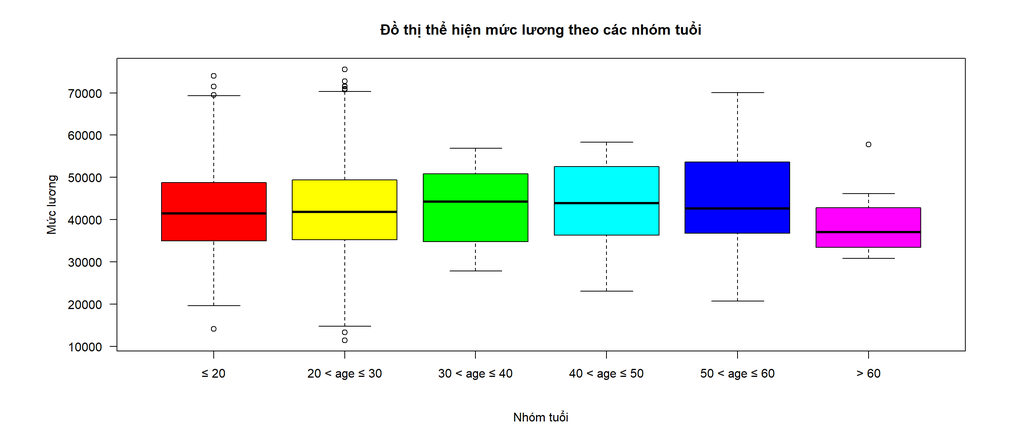

```r
oldpar <- par(no.readonly = TRUE)
par(mar = c(6, 8, 4, 4))
par(mgp = c(4, 1, 0))
boxplot(formula = salary ~ group_age,
        data = df_salary,
        col = rainbow(n = 6),
        las = 1,
        xlab = "Nhóm tuổi",
        ylab = "Mức lương",
        main = "Đồ thị thể hiện mức lương theo các nhóm tuổi")
```

```r
par(oldpar)
```

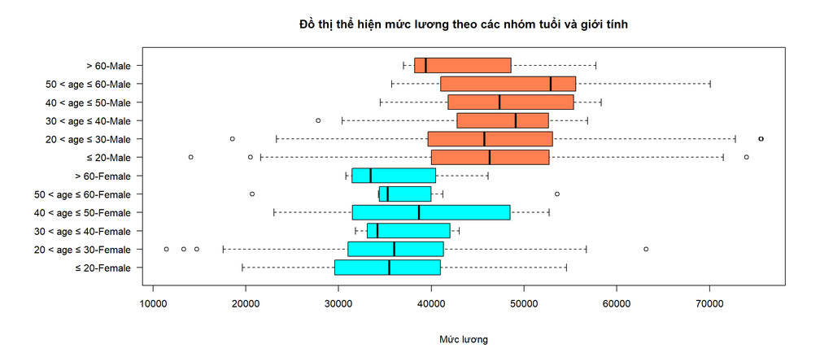

```r
oldpar <- par(no.readonly = TRUE)
par(mar = c(6, 12, 4, 4))
par(mgp = c(4, 1, 0))
boxplot(formula = salary ~ group_age + gender,
        data = df_salary,
        col = c(rep("cyan", 6), rep("coral", 6)),
        las = 1,
        xlab = "Mức lương",
        ylab = "",
        horizontal = TRUE,
        sep = "-",
        lex.order = FALSE,
        # names = c(letters[1:12]),
        main = "Đồ thị thể hiện mức lương theo các nhóm tuổi và giới tính")
```

```r
par(oldpar)
```

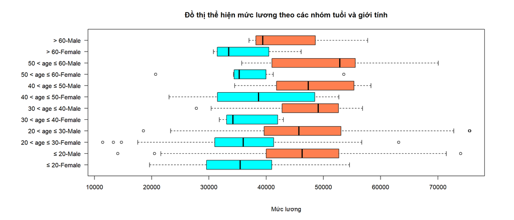

```r
oldpar <- par(no.readonly = TRUE)
par(mar = c(6, 12, 4, 4))
par(mgp = c(4, 1, 0))
boxplot(formula = salary ~ group_age + gender,
        data = df_salary,
        col = rep(c("cyan", "coral"), 6),
        las = 1,
        xlab = "Mức lương",
        ylab = "",
        horizontal = TRUE,
        sep = "-",
        lex.order = TRUE,
        # names = c(letters[1:12]),
        main = "Đồ thị thể hiện mức lương theo các nhóm tuổi và giới tính")
```

```r
par(oldpar)
```

```r
df_salary |> dplyr::group_by(gender, group_age) |>
  dplyr::summarise(trung_binh_salary = mean(salary),
                   trung_vi_salary = median(salary),
                   do_lech_chuan_salary = sd(salary),
                   max_salary = max(salary),
                   min_salary = min(salary),
                   so_luong = n()) -> summary_salary

as.data.frame(summary_salary)
```

```
   gender     group_age trung_binh_salary trung_vi_salary do_lech_chuan_salary max_salary min_salary so_luong
1  Female          ≤ 20          35559.89        35470.46             7704.974   54590.09   19636.59      232
2  Female 20 < age ≤ 30          36167.63        35987.41             7718.234   63154.33   11444.14      413
3  Female 30 < age ≤ 40          37033.79        34200.54             5025.071   43000.51   31806.92        7
4  Female 40 < age ≤ 50          39263.15        38688.85             9980.751   52691.50   23044.40       10
5  Female 50 < age ≤ 60          36698.65        35282.33             9103.857   53565.90   20690.65        8
6  Female          > 60          35965.51        33467.47             6982.298   46130.95   30796.16        4
7    Male          ≤ 20          46524.48        46306.62             9662.660   73980.21   14081.10      345
8    Male 20 < age ≤ 30          46510.91        45709.30             9695.876   75596.79   18571.24      680
9    Male 30 < age ≤ 40          46259.95        49103.72             8761.094   56853.81   27821.99       17
10   Male 40 < age ≤ 50          47586.86        47360.78             8112.779   58316.01   34491.28       15
11   Male 50 < age ≤ 60          50107.44        52875.74            10326.033   70094.85   35727.41       19
12   Male          > 60          44729.42        39413.49            11353.582   57765.71   37009.08        3
```

## 4.4 Vẽ nhiều đồ thị con trong một hình

Vẽ đồ thị giữa `height` và `weight`

```r
df_height <- df[, c("age", "gender", "major", "height", "weight", "salary")]

head(df_height, n = 30)
```

```
   age gender                      major height weight   salary
1   19 Female          Political Science    160   64.8       NA
2   19 Female            Social Sciences    172   73.0       NA
3   22 Female            Social Sciences    168   70.6       NA
4   19   Male     Environmental Sciences    183   79.7       NA
5   21 Female     Environmental Sciences    175   71.4       NA
6   19   Male          Political Science    189   85.8       NA
7   21 Female          Political Science    156   65.9       NA
8   21 Female          Political Science    167   65.7       NA
9   18   Male      Economics and Finance    195   94.4       NA
10  18 Female     Environmental Sciences    165   66.0       NA
11  22 Female      Economics and Finance    162   66.8 45254.11
12  18 Female     Environmental Sciences    172   66.8       NA
13  23   Male     Environmental Sciences    185   84.6 40552.79
14  20 Female     Environmental Sciences    158   64.4 27007.03
```

[output cut: 16 more lines]

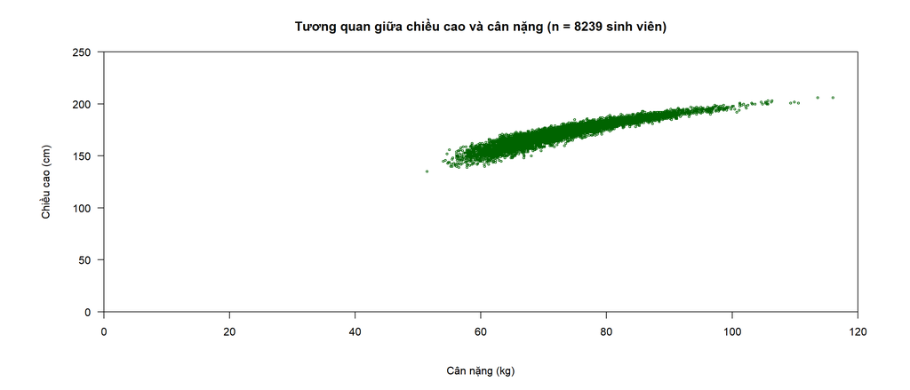

```r
oldpar <- par(no.readonly = TRUE)
par(mar = c(6, 8, 4, 4))
par(mgp = c(4, 1, 0))
plot(x = df_height$weight,
     y = df_height$height,
     type = "p",
     col = "darkgreen",
     pch = 1,
     cex = 0.5,
     xlim = c(0, 120),
     ylim = c(0, 250),
     las = 1,
     xaxs = "i",
     yaxs = "i",
     xlab = "Cân nặng (kg)",
     ylab = "Chiều cao (cm)",
     main = paste0("Tương quan giữa chiều cao và cân nặng (n = ",
                  dim(df_height)[1], " sinh viên)"),
     lwd = 1,
     lty = 1,
     bty = "o")
```

```r
par(oldpar)
```

Tô màu theo `gender`

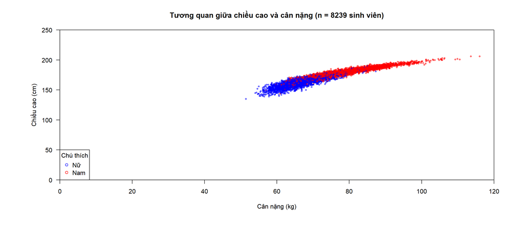

```r
df_height <- df[, c("age", "gender", "religion", "height", "weight", "salary")]

col_1 <- factor(df_height$gender)

oldpar <- par(no.readonly = TRUE)
par(mar = c(6, 8, 4, 4))
# par(mgp = c(4, 1, 0))
plot(x = df_height$weight,
     y = df_height$height,
     type = "p",
     col = c("blue", "red")[col_1],
     pch = 1,
     cex = 0.5,
     xlim = c(0, 120),
     ylim = c(0, 250),
     las = 1,
     xaxs = "i",
     yaxs = "i",
     xlab = "Cân nặng (kg)",
     ylab = "Chiều cao (cm)",
     main = paste0("Tương quan giữa chiều cao và cân nặng (n = ",
                  dim(df_height)[1], " sinh viên)"),
     lwd = 1,
     lty = 1,
     bty = "o")

legend(x = "bottomleft",
       y = NULL,
       title = "Chú thích",
       legend = c("Nữ", "Nam"),
       # horiz = TRUE,
       col = c("blue", "red"),
       # fill = c("blue", "red"),
       pch = 1,
       xpd = TRUE)
```

```r
par(oldpar)
```

### 4.4.1 Sử dụng package `lattice` vẽ đồ thị scatterplot

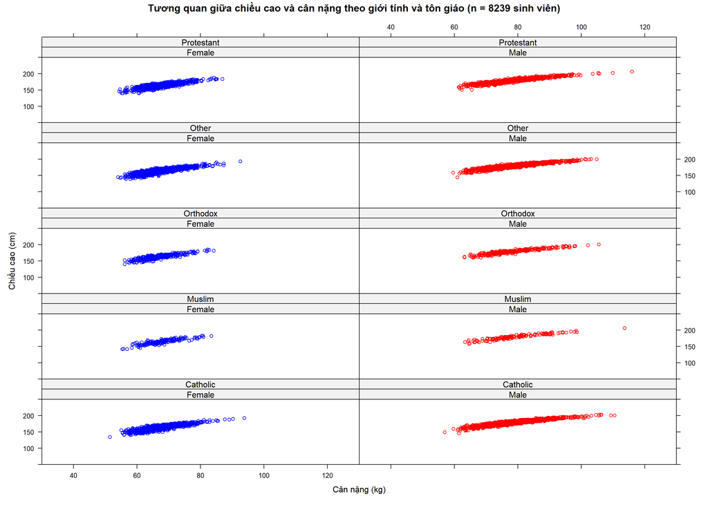

```r
library(lattice)

lattice::xyplot(x = height ~ weight | gender + religion,
                groups = gender,
                col = c("blue", "red"),
                origin = 0,
                xlim = c(30, 130),
                ylim = c(50, 250),
                xlab = "Cân nặng (kg)",
                ylab = "Chiều cao (cm)",
                main = paste0("Tương quan giữa chiều cao và cân nặng theo giới tính và tôn giáo (n = ",
                  dim(df_height)[1], " sinh viên)"),
                data = df_height)
```

### 4.4.2 Vẽ đồ thị nhiều biến

```r
df_clean <- df[, c("age", "gender", "religion", "height", "weight", "salary")]

df_clean <- na.omit(df_clean)

df_clean$group_age <- cut(x = df_clean$age,
                           breaks = c(0, 20, 30, 40, 50, 60, 70),
                           labels = c("≤ 20",
                                      "20 < age ≤ 30",
                                      "30 < age ≤ 40",
                                      "40 < age ≤ 50",
                                      "50 < age ≤ 60",
                                      "> 60"))

df_clean |> dplyr::arrange(age) -> df_clean

as.data.frame(table(df_clean$group_age))
```

```
           Var1 Freq
1          ≤ 20  577
2 20 < age ≤ 30 1093
3 30 < age ≤ 40   24
4 40 < age ≤ 50   25
5 50 < age ≤ 60   27
6          > 60    7
```

```r
library(lattice)

head(df_clean)
```

```
  age gender   religion height weight   salary group_age
1  18   Male Protestant    178   74.3 51564.04      ≤ 20
2  18   Male   Catholic    190   91.4 43332.84      ≤ 20
3  18   Male Protestant    186   84.2 64525.11      ≤ 20
4  18   Male   Catholic    187   84.4 37691.93      ≤ 20
5  18   Male   Catholic    169   68.9 38422.71      ≤ 20
6  18   Male      Other    192   92.2 34460.44      ≤ 20
```

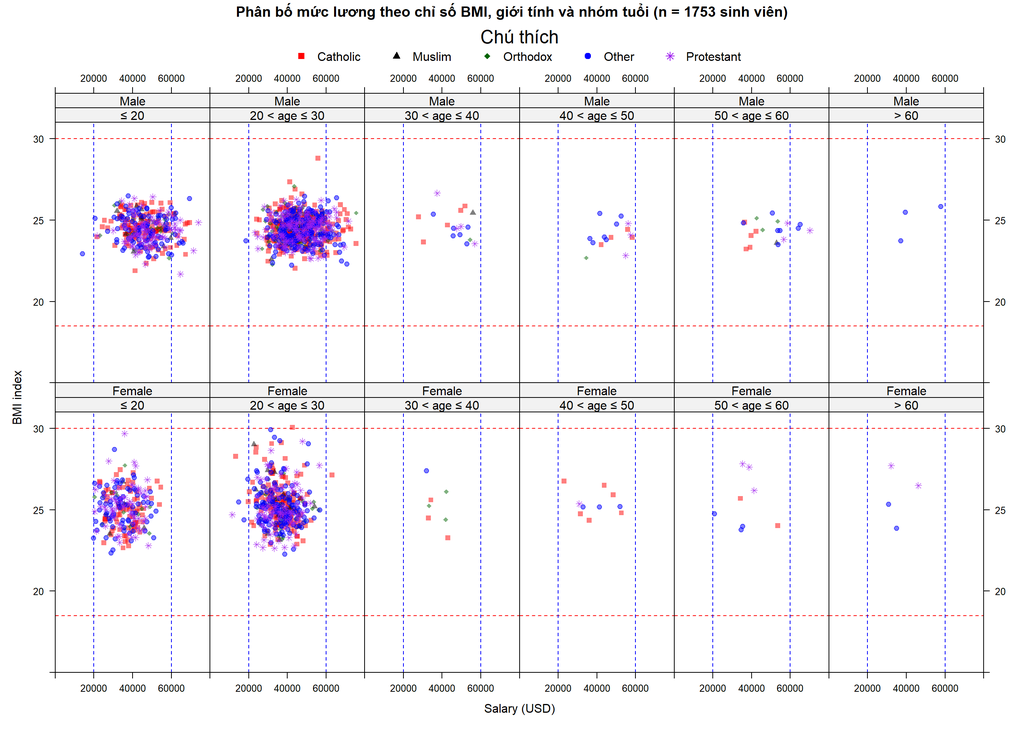

```r
options(scipen = 10)

df_clean$bmi <- df_clean$weight / (df_clean$height * 0.01)^2

df_clean$religion <- factor(df_clean$religion)
labels <- levels(df_clean$religion)

lattice::xyplot(x = bmi ~ salary | group_age + gender,
                groups = religion,
                col = adjustcolor(col = c("red", "black", "darkgreen", "blue", "purple"),
                                  alpha.f = 0.5),
                pch = c(15, 17, 18, 19, 8),
                origin = 0,
                ylim = c(15, 31),
                xlim = c(0, 80000),
                xlab = "Salary (USD)",
                ylab = "BMI index",
                main = paste0("Phân bố mức lương theo chỉ số BMI, giới tính và nhóm tuổi (n = ",
                  dim(df_clean)[1], " sinh viên)"),
                key = list(space = "top",
                         columns = 5,
                         title = "Chú thích",
                         points=list(pch = c(15, 17, 18, 19, 8),
                                     col = adjustcolor(col = c("red", "black", "darkgreen", "blue", "purple"),
                                                       alpha.f = 1)),
                         text = list(labels)),
                scale = list(alternating = 3, rot = 0),
                panel = function(...) {
                   panel.abline(h = 30, col = "red", lty = 2)
                   panel.abline(h = 18.5, col = "red", lty = 2)

                   panel.abline(v = 20000, col = "blue", lty = 2)
                   panel.abline(v = 60000, col = "blue", lty = 2)
                   panel.xyplot(...)
                 },
                data = df_clean)
```

### 4.4.3 Vẽ đồ thị histogram

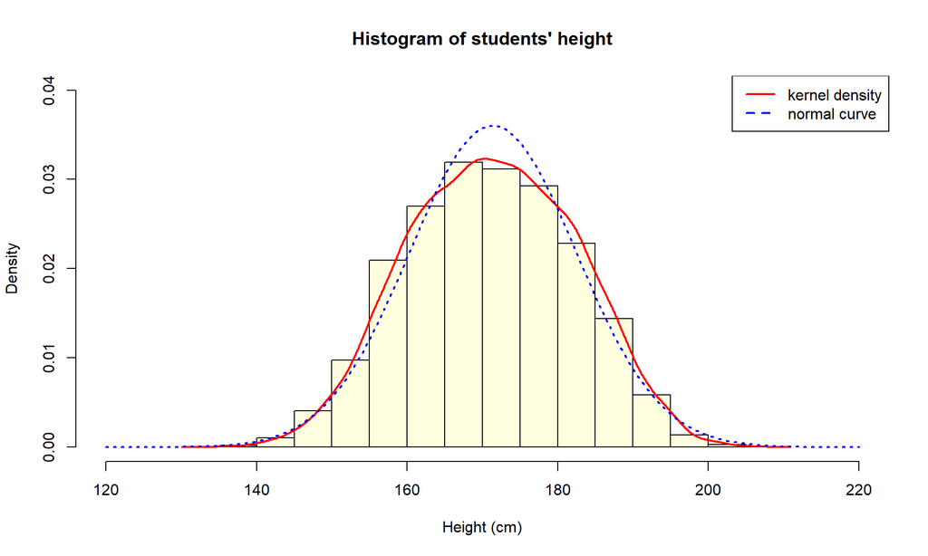

```r
height_data <- hist(df$height,
     col = "lightyellow",
     main = "Histogram of students' height",
     xlab = "Height (cm)",
     ylab = "Density",
     xlim = c(120, 220),
     ylim = c(0, 0.04),
     probability = TRUE)

lines(density(df$height),
      col = "red",
      lty = 1,
      lwd = 2)

day_so <- seq(from = min(df$height, na.rm = TRUE),
              to = max(df$height, na.rm = TRUE),
              length = 1000)

curve(expr = dnorm(day_so,
            mean = mean(df$height, na.rm = TRUE),
            sd = sd(df$height, na.rm = TRUE)),
      type = "l",
      add = TRUE,
      lwd = 2,
      xname = "day_so",
      col = "blue",
      lty = "dotted")

legend(x = "topright",
       y = NULL,
       legend = c("kernel density", "normal curve"),
       col = c("red", "blue"),
       lwd = 2,
       lty = c(1, 2))
```

```r
height_data
```

```
$breaks
 [1] 135 140 145 150 155 160 165 170 175 180 185 190 195 200 205 210

$counts
 [1]    7   43  167  402  862 1111 1314 1284 1206  940  593  240   56   12    2

$density
 [1] 1.699235e-04 1.043816e-03 4.053890e-03 9.758466e-03 2.092487e-02 2.696929e-02 3.189707e-02 3.116883e-02 2.927540e-02 2.281830e-02 1.439495e-02 5.825950e-03 1.359388e-03 2.912975e-04 4.854958e-05

$mids
 [1] 137.5 142.5 147.5 152.5 157.5 162.5 167.5 172.5 177.5 182.5 187.5 192.5 197.5 202.5 207.5

$xname
[1] "df$height"

$equidist
[1] TRUE

attr(,"class")
[1] "histogram"
```

# 5 Tài liệu tham khảo

1. https://stackoverflow.com/questions/6451152/how-to-catch-integer0
2. https://amices.org/mice/
3. https://amices.org/Winnipeg/
4. https://www.geeksforgeeks.org/addmargins-function-in-r/
5. https://sparkbyexamples.com/r-programming/group-by-summarise-in-r/
6. https://dplyr.tidyverse.org/reference/sample_n.html
7. https://www.calculator.net/bmi-calculator.html
8. https://www.statology.org/overlay-normal-curve-histogram-in-r/
9. https://www.geo.fu-berlin.de/en/v/soga-r/Basics-of-statistics/Descriptive-Statistics/Measures-of-Dispersion/Variance-and-Standard-Deviation/index.html

## Footnotes

[^1]: https://bookdown.org/yihui/rmarkdown-cookbook/kableextra.html
[^2]: https://datascienceplus.com/imputing-missing-data-with-r-mice-package/